# noisy_bb_learning_measurement

anjie

5/12/2021

```r
library(tidyverse)
library(here)
source(here("adult_modeling/scripts/get_entropy.R"))
source(here("adult_modeling/scripts/get_KL_measurement.R"))
source(here("adult_modeling/scripts/get_surprise.R"))
```

# first load the updates

Stimuli seqeuence: - 8 trial, deviants at 3rd and 5th trial  
- total feature 100; simple feature n = 30 , complex feature = 80; deviants have 20% different features - all feature theta = 0.8; all non-feature theta = 0.2

observation sequence: - each trial has 10 observations - epsilon = 0.02

noisy observation update: - grid theta and grid epsilon: seq(0.1, 1, 0.2) - alpha_prior = 1; beta_prior = 1 - alpha_epsilon = 1; beta_epsilon = 10

```r
s_a1b1 <- readRDS(here("adult_modeling/m_res/obs_1_sequential_update.rds"))
c_a1b1 <- readRDS(here("adult_modeling/m_res/obs_2_sequential_update.rds"))

s_a1b5 <- readRDS(here("adult_modeling/m_res/obs_1_a1b5_sequential_update.rds"))
c_a1b5 <- readRDS(here("adult_modeling/m_res/obs_2_a1b5_sequential_update.rds"))

s_a5b1 <- readRDS(here("adult_modeling/m_res/obs_1_a5b1_sequential_update.rds"))
c_a5b1 <- readRDS(here("adult_modeling/m_res/obs_2_a5b1_sequential_update.rds"))
```

# KL divergence

here we calculate the expected information gain (EIG) for a new observation $z_{t+1}$ at time point $t$

$$D_{KL}(p(\theta|z_{i+1}) || p(\theta|z_{i})) = \sum_{\theta \in [\theta_{1}, \theta_{2}...\theta_{d}]} p(\theta|z_{i+1}) log\frac{p(\theta|z_{i+1})}{p(\theta|z_{i}))}$$

So for each observation at time point $z_{t+1}$, we summed over all the possible grid
$$\theta$$
value.

```r
kl_s_a1b1 <- readRDS(here("adult_modeling/m_res/obs_1_sequential_update_kl.rds")) %>%
  mutate(complexity = "simple",
         params = "a1b1")

kl_c_a1b1 <- readRDS(here("adult_modeling/m_res/obs_2_sequential_update_kl.rds")) %>%
  mutate(complexity = "complex",
         params = "a1b1")

kl_s_a1b5 <- readRDS(here("adult_modeling/m_res/obs_1_a1b5_sequential_update_kl.rds")) %>%
  mutate(complexity = "simple",
         params = "a1b5")

kl_c_a1b5 <- readRDS(here("adult_modeling/m_res/obs_2_a1b5_sequential_update_kl.rds")) %>%
  mutate(complexity = "complex",
         params = "a1b5")

kl_s_a5b1 <- readRDS(here("adult_modeling/m_res/obs_1_a5b1_sequential_update_kl.rds")) %>%
  mutate(complexity = "simple",
         params = "a5b1")

kl_c_a5b1 <- readRDS(here("adult_modeling/m_res/obs_2_a5b1_sequential_update_kl.rds")) %>%
  mutate(complexity = "complex",
         params = "a5b1")#needs rerun

kl_all <- bind_rows(kl_s_a1b1,
                    kl_c_a1b1,
                    kl_s_a1b5,
                    kl_c_a1b5,
                    kl_s_a5b1,
                    kl_c_a5b1)

kl_all %>%
  filter(complexity == "complex")
```

```
## # A tibble: 23,700 x 7
##         kl update_step feature_index trial_num trial_observation_num complexity
##      <dbl>       <dbl>         <dbl>     <int>                 <dbl> <chr>
##  1 0.0998            2             1         1                    10 complex
##  2 0.0600            3             1         1                    10 complex
##  3 0.0387            4             1         1                    10 complex
##  4 0.0264            5             1         1                    10 complex
##  5 0.0188            6             1         1                    10 complex
##  6 0.0138            7             1         1                    10 complex
##  7 0.0104            8             1         1                    10 complex
##  8 0.00791           9             1         1                    10 complex
##  9 0.00612          10             1         1                    10 complex
## 10 0.00477          11             1         2                    10 complex
## # … with 23,690 more rows, and 1 more variable: params <chr>
```

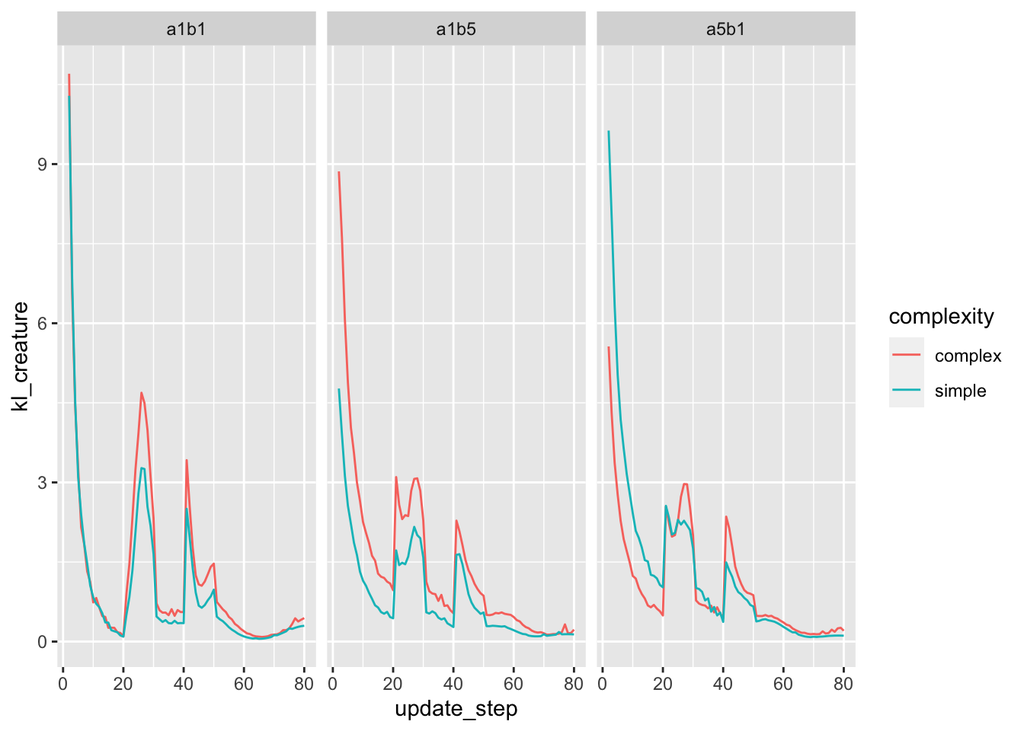

```r
kl_all %>%
  group_by(update_step, complexity, params) %>%
  summarise(kl_creature = sum(kl)) %>%
  ggplot(aes(x = update_step,
             y = kl_creature,
             color = complexity)) +
  geom_line() +
  facet_wrap(~params)
```

# entropy

following the notation given in:http://todd.gureckislab.org/2021/05/05/negative-information

The prior is so the entropy at timestep 0 is
$$g_0 = H(\theta) = -\sum_{\theta}p(\theta)logp(\theta)$$

and after i update the entropy will become
$$g_{i}(z_i) = H(\theta|z_i) = -\sum_{\theta}p(\theta|z_i)logp(\theta|z_i)$$

translate the computation to code looks something like this:

```r
get_entropy_for_feature_one_update <- function(lps){
  -sum(lps * exp(lps))
}
```

Poli uses negative entropy as a measurement for predictability, so here we will do something similar.

```r
s_a1b1_e <- get_entropy_for_creature_udpates(s_a1b1) %>%
  mutate(complexity = "simple",
         params = "a1b1")
c_a1b1_e <- get_entropy_for_creature_udpates(c_a1b1) %>%
  mutate(complexity = "complex",
         params = "a1b1")

s_a1b5_e <- get_entropy_for_creature_udpates(s_a1b5) %>%
  mutate(complexity = "simple",
         params = "a1b5")

c_a1b5_e <- get_entropy_for_creature_udpates(c_a1b5)%>%
  mutate(complexity = "complex",
         params = "a1b5")

s_a5b1_e <- get_entropy_for_creature_udpates(s_a5b1)%>%
  mutate(complexity = "simple",
         params = "a5b1")
c_a5b1_e <- get_entropy_for_creature_udpates(c_a5b1)%>%
  mutate(complexity = "complex",
         params = "a5b1")

e_all <- bind_rows(s_a1b1_e, c_a1b1_e,
                   s_a1b5_e, c_a1b5_e,
                   s_a5b1_e, c_a5b1_e)
```

a little bit weird, shouldn’t this be upside down? this is the entropy not the negative entropy aka the surprise

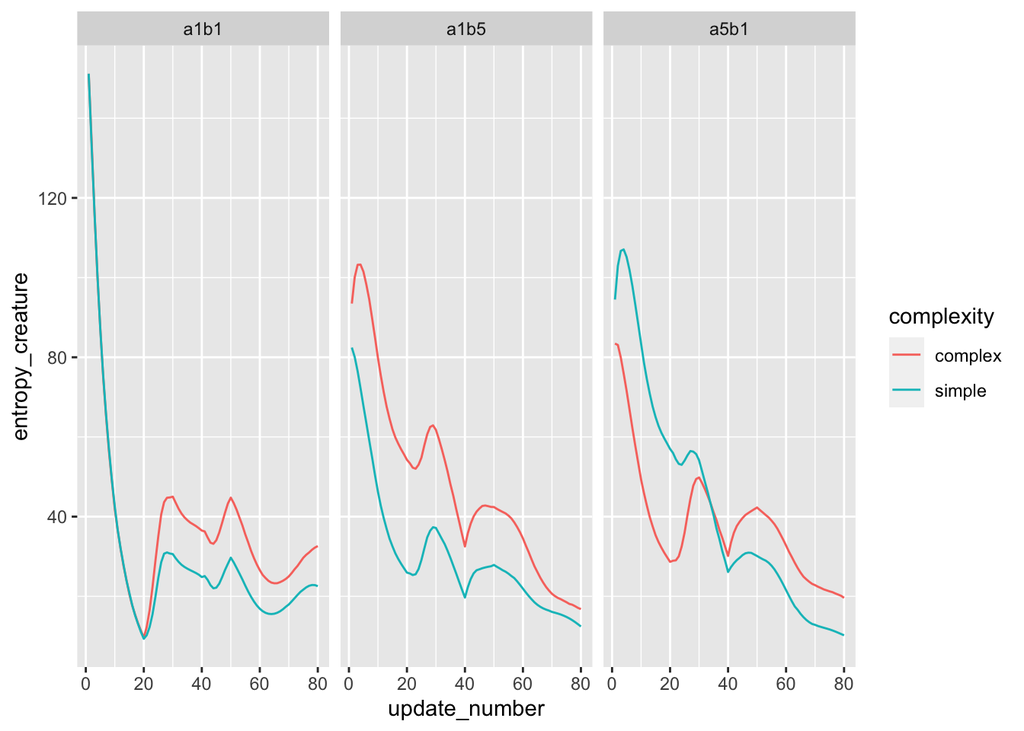

```r
e_all %>%
  group_by(update_number, complexity, params) %>%
  summarise(entropy_creature = sum(e)) %>%
  ggplot(aes(x = update_number,
             y = entropy_creature,
             color = complexity)) +
  geom_line() +
  facet_wrap(~params)
```

# surprisal

this is what got me confused the most. currently calculating as: surprisal at observation $z_{t}$ just the weighted average of the surprisal for each value of theta, and take the average of those surprisals weighed by p(theta = this_particular_value_of_theta|z) (so doing an weighted average over
$$p(\theta|z_{t}))$$
?

this is looks exactly like the entropy so i must be doing something wrong?? unless they are technically the same thing?

```r
s_a1b1_s <- get_surprise_for_creature_updates(s_a1b1) %>%
  mutate(complexity = "simple",
         params = "a1b1")
c_a1b1_s <- get_surprise_for_creature_updates(c_a1b1) %>%
  mutate(complexity = "complex",
         params = "a1b1")

s_a1b5_s <- get_surprise_for_creature_updates(s_a1b5) %>%
  mutate(complexity = "simple",
         params = "a1b5")

c_a1b5_s <- get_surprise_for_creature_updates(c_a1b5)%>%
  mutate(complexity = "complex",
         params = "a1b5")

s_a5b1_s <- get_surprise_for_creature_updates(s_a5b1)%>%
  mutate(complexity = "simple",
         params = "a5b1")
c_a5b1_s <- get_surprise_for_creature_updates(c_a5b1)%>%
  mutate(complexity = "complex",
         params = "a5b1")

s_all <- bind_rows(s_a1b1_s, c_a1b1_s,
                   s_a1b5_s, c_a1b5_s,
                   s_a5b1_s, c_a5b1_s)
```

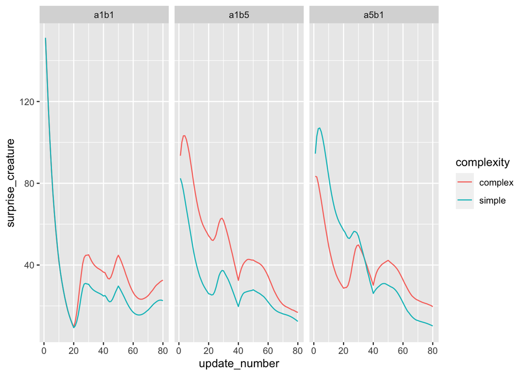

```r
s_all %>%
  group_by(update_number, complexity, params) %>%
  summarise(surprise_creature = sum(surprise)) %>%
  ggplot(aes(x = update_number,
             y = surprise_creature,
             color = complexity)) +
  geom_line() +
  facet_wrap(~params)
```

# conceptula understanding to-do

how do these terms related to one another? - expected information gain - information gain - surprise - entropy - KL divergence